Skip to main content

# Burtin’s Bacteria

Author

Theresa Louise Binnings

## Burtin’s Bacteria

Doctors need to be able to make quick decisions about which antibiotics to prescribe when a patient has a bacterial infection. Different bacteria respond differently to various antibiotics. Additionally, it can take too much time to identify a particular bacterial strain; Gram Staining is an assessment that can be done within the clinic to help “type” the bacteria and more quickly assess which antibiotic to use.

Minimum Inhibitory Concentration (MIC) is commonly used as a measure of how effective an antibiotic is at killing a bacteria. The numeric measure can be thought of as measuring how much antibiotic is needed in a petri dish in order to kill the bacteria; **a smaller number is better because it means the antibiotic was more effective at killing the bacteria with a smaller dose.**

After World War II, antibiotics earned the moniker “wonder drugs” for quickly treating previously-incurable diseases. Data was gathered to determine which drug worked best for each bacterial infection. Comparing drug performance was an enormous aid for practitioners and scientists alike.

In the fall of 1951, German graphic designer William Burtin gathered data on the MIC of three antibiotics for 16 different bacteria. Each bacteria was classified according to Gram Staining: Positive/Negative.

In this project, you will create visualizations to answer three questions. One of the goals of the design task is to answer all three questions with no more than three visualizations, preferably fewer (i.e., try to answer all three questions in fewer than 3 visualizations). All visualizations will be organized on a single static dashboard using the **`dashboard`** Quarto format. Find more information [**HERE**](https://quarto.org/docs/dashboards/). I have provided an example in this project folder (*warning* - it contains bad visualizations for demonstration purposes).

**Here are the questions to be answered:**

- Which bacteria was the hardest to kill? Easiest to kill?
- Was one antibiotic the most effective overall?
- Did the effectiveness of each antibiotic vary by gram staining?

```r
antibio_wide <- read_csv("Burtin_Antibiotics.csv")
antibio_wide |> head()
```

```
# A tibble: 6 × 6
  Bacteria               BacteriaAbbr Penicilin Streptom Neomycin Gram_Staining
  <chr>                  <chr>            <dbl>    <dbl>    <dbl> <chr>
1 Aerobacter aerogenes   Aerobact       870         1       1.6   negative
2 Brucella abortus       Brucella ab      1         2       0.02  negative
3 Brucella antracis      Brucella an      0.001     0.01    0.007 positive
4 Diplococcus pneumoniae Diplococc        0.005    11      10     positive
5 Escherichia coli       Escherichi     100         0.4     0.1   negative
6 Klebsiella pneumoniae  Klebsiella     850         1.2     1     negative
```

Here is another reformulation of the same data that may or may not be useful, depending on the visualization you design.

```r
antibio_long <- read_csv("Burtin_Antibiotics_Alt.csv")
antibio_long |> head()
```

```
# A tibble: 6 × 5
  Bacteria             BacteriaAbbr Gram_Staining Antibiotic    MIC
  <chr>                <chr>        <chr>         <chr>       <dbl>
1 Aerobacter aerogenes Aerobact     negative      Penicilin  870
2 Aerobacter aerogenes Aerobact     negative      Streptom     1
3 Aerobacter aerogenes Aerobact     negative      Neomycin     1.6
4 Brucella abortus     Brucella ab  negative      Penicilin    1
5 Brucella abortus     Brucella ab  negative      Streptom     2
6 Brucella abortus     Brucella ab  negative      Neomycin     0.02
```

Remember, you can also create new variables if that is helpful, for example:

```r
antibio_new <- antibio_wide |>
  mutate(MIC_total = Penicilin + Streptom + Neomycin)

antibio_new |> head()
```

```
# A tibble: 6 × 7
  Bacteria      BacteriaAbbr Penicilin Streptom Neomycin Gram_Staining MIC_total
  <chr>         <chr>            <dbl>    <dbl>    <dbl> <chr>             <dbl>
1 Aerobacter a… Aerobact       870         1       1.6   negative        873.
2 Brucella abo… Brucella ab      1         2       0.02  negative          3.02
3 Brucella ant… Brucella an      0.001     0.01    0.007 positive          0.018
4 Diplococcus … Diplococc        0.005    11      10     positive         21.0
5 Escherichia … Escherichi     100         0.4     0.1   negative        100.
6 Klebsiella p… Klebsiella     850         1.2     1     negative        852.
```

```r
antibio_long <- antibio_long |>
  mutate(Antibiotic = case_match(Antibiotic,
                    "Penicilin" ~ "Penicillin",
                    "Streptom" ~ "Streptomycin",
                    .default = Antibiotic))


antibio_long_new <- antibio_long |>
  select(Bacteria, Gram_Staining) |>
  distinct(Bacteria, Gram_Staining) |>
  mutate(most_effective =
           case_when(Bacteria == "Streptococcus viridans" ~ "Penicillin",
                     Bacteria == "Streptococcus hemolyticus" ~ "Penicillin",
                     Bacteria == "Diplococcus pneumoniae" ~ "Penicillin",
                     Bacteria == "Streptococcus fecalis" ~ "Neomycin",
                     Bacteria == "Staphylococcus albus" ~ "Neomycin",
                     Bacteria == "Staphylococcus aureus" ~ "Neomycin",
                     Bacteria == "Brucella antracis" ~ "Penicillin",
                     Bacteria == "Mycobacterium tuberculosis" ~ "Neomycin",
                     Bacteria == "Aerobacter aerogenes" ~ "Streptomycin",
                     Bacteria == "Klebsiella pneumoniae" ~ "Neomycin",
                     Bacteria == "Pseudomonas aeruginosa" ~ "Neomycin",
                     Bacteria == "Escherichia coli" ~ "Neomycin",
                     Bacteria == "Salmonella schottmuelleri" ~ "Neomycin",
                     #Bacteria == "Proteus vulgaris" ~ "Neomycin & Streptomycin",
                     Bacteria == "Proteus vulgaris" ~ "Neomycin",
                     Bacteria == "Brucella abortus" ~ "Neomycin",
                     Bacteria == "Salmonella (Eberthella) typhosa" ~"Neomycin")) |>
  add_row(Bacteria = "Proteus vulgaris",
          Gram_Staining = "negative",
          most_effective = "Streptomycin")

antibio_long_new |> head()
```

```
# A tibble: 6 × 3
  Bacteria               Gram_Staining most_effective
  <chr>                  <chr>         <chr>
1 Aerobacter aerogenes   negative      Streptomycin
2 Brucella abortus       negative      Neomycin
3 Brucella antracis      positive      Penicillin
4 Diplococcus pneumoniae positive      Penicillin
5 Escherichia coli       negative      Neomycin
6 Klebsiella pneumoniae  negative      Neomycin
```

## Visualizations

Use this Quarto file to explore the data and **develop** your graphs. You will then copy and paste your graph code in to the Dashboard document for your final product. *Note that the dashboard also has a second tab where you need to answer 4 questions!*

Remember you can have AT MOST 3 visualizations to help you answer the three questions:

- Which bacteria was the hardest to kill? Easiest to kill?
- Was one antibiotic the most effective overall?b
- Did antibiotic effectiveness vary by gram staining?

Consider adding annotations to your visualizations and dashboards to help clarify the message of your visualizations.

```r
#esquisse::esquisser(data) remember you can use this to get started but you will need to make some more adjustments
#BE CAREFUL - the default geometry esquisse chooses are not always correct or best!
```

### Scatterplot

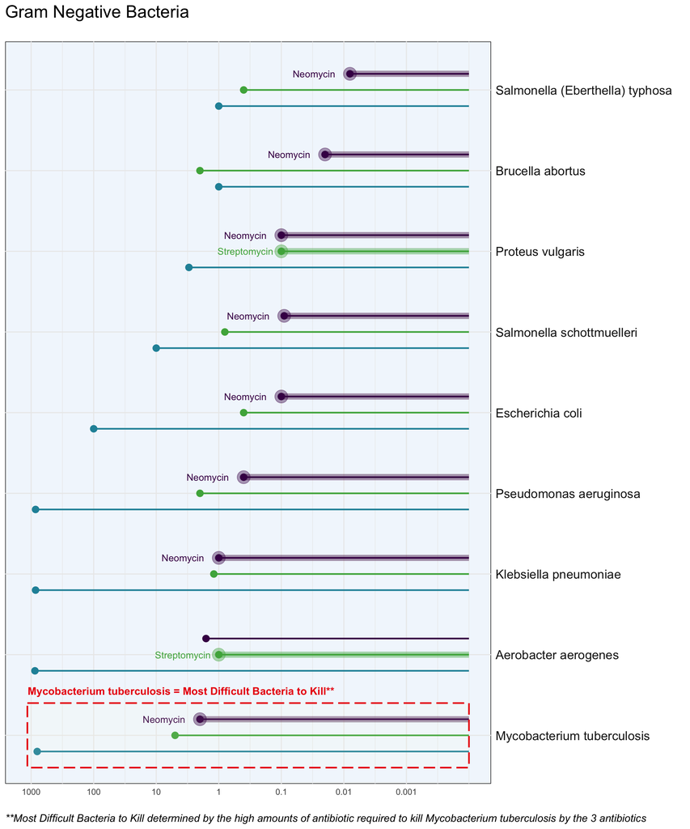

```r
picks <- antibio_long_new |>
  select(Bacteria, Antibiotic = most_effective) |>
  mutate(label = Antibiotic)

antibio_labelled <-antibio_long |>
   left_join(picks, by = c("Bacteria", "Antibiotic")) |>
   mutate(label = coalesce(label, ""))


antibio_labelled |>
  filter(Gram_Staining == "negative") |>
  ggplot(aes(y = fct_relevel(Bacteria, c("Mycobacterium tuberculosis",
                                         "Aerobacter aerogenes",
                                         "Klebsiella pneumoniae",
                                         "Pseudomonas aeruginosa",
                                         "Escherichia coli",
                                         "Salmonella schottmuelleri",
                                         "Proteus vulgaris",
                                         "Brucella abortus",
                                         "Salmonella (Eberthella) typhosa")),
             colour = fct_relevel(Antibiotic,  c("Penicillin", "Streptomycin", "Neomycin")))) +
  geom_point(aes(x = MIC), position = position_dodge(width = 0.6), size = 3) +
  scale_y_discrete(position = "right") +
  geom_segment(aes(x = 0.0001, y = 1.2, xend = 2, yend = 1.2), linewidth = 3, color = alpha("#440154FF", 0.02)) +
  geom_segment(aes(x = 0.0001, y = 2, xend = 1, yend = 2), linewidth = 3, color = alpha("#4daf4a", 0.02)) +
  geom_segment(aes(x = 0.0001, y = 3.2, xend = 1, yend = 3.2), linewidth = 3, color = alpha("#440154FF", 0.02)) +
  geom_segment(aes(x = 0.0001, y = 4.2, xend = 0.4, yend = 4.2), linewidth = 3, color = alpha("#440154FF", 0.02)) +
  geom_segment(aes(x = 0.0001, y = 5.2, xend = 0.1, yend = 5.2), linewidth = 3, color = alpha("#440154FF", 0.02)) +
  geom_segment(aes(x = 0.0001, y = 6.2, xend = 0.09, yend = 6.2), linewidth = 3, color = alpha("#440154FF", 0.02)) +
  geom_segment(aes(x = 0.0001, y = 7.2, xend = 0.1, yend = 7.2), linewidth = 3, color = alpha("#440154FF", 0.02)) +
  geom_segment(aes(x = 0.0001, y = 8.2, xend = 0.02, yend = 8.2), linewidth = 3, color = alpha("#440154FF", 0.02)) +
  geom_segment(aes(x = 0.0001, y = 9.2, xend = 0.008, yend = 9.2), linewidth = 3, color = alpha("#440154FF", 0.02)) +
  geom_segment(aes(x = 0.0001, y = 7, xend = 0.1, yend = 7), linewidth = 3, color = alpha("#4daf4a", 0.02)) +
  geom_linerange(aes(xmin = 0.0001, xmax = MIC), position = position_dodge(width = 0.6), linewidth = 0.8) +
  scale_color_manual(values = c("#2291A7","#4daf4a", "#440154FF")) +
  scale_x_continuous(transform = c("log10", "reverse"),
                     limits =  c(0.0001, 1151),
                     breaks = c(1000, 100, 10, 1.0, 0.1, 0.01, 0.001),
                     labels =  c(1000, 100, 10, 1.0, 0.1, 0.01, 0.001)) +
  theme_minimal() +
  labs(title = "Gram Negative Bacteria",
       subtitle = "",
       x = "",
       y = "",
       color = "",
       shape = "",
       caption = "**Most Difficult Bacteria to Kill determined by the high amounts of antibiotic required to kill Mycobacterium tuberculosis by the 3 antibiotics") +
  theme(axis.text.y.right = element_text(hjust = 0,
                                         size = 13,
                                         color = "grey10"),
        panel.background = element_rect(fill = scales::alpha("#72ADE9", 0.1)),
        plot.caption = element_text(size = 11, face = "italic", hjust = 0),
        plot.title = element_text(size = 18)) +
  guides(color = "none") +
  # new_scale_color() +
  geom_text(aes(x = MIC*3.75, label = label), position = position_dodge(width = 0.6), size = 3.5) +
  # scale_color_manual(values = c("Neomycin" = "#187E93",
  #                                 "Streptomycin" = "#4A7F0F",
  #                                 "Penicillin" = "#440154FF"),
  #                               guide = "none") +
  annotate("rect", xmin = 0.0001, xmax = 1150, ymin = 0.6, ymax = 1.4, linetype = "longdash", color = "#EB0C0C", fill = alpha("lightyellow", 0.09), linewidth = 0.8) +
  annotate("text", x = 4, y = 1.55, color = "#EB0C0C", label = "Mycobacterium tuberculosis = Most Difficult Bacteria to Kill**", fontface = "bold") +
  annotate("point", x = 2, y = 1.2, size = 6, color = alpha("#440154FF", 0.4)) +
  annotate("point", x = 1, y = 2, size = 6, color = alpha("#4daf4a", 0.4)) +
  annotate("point", x = 1, y = 3.2, size = 6, color = alpha("#440154FF", 0.4)) +
  annotate("point", x = 0.4, y = 4.2, size = 6, color = alpha("#440154FF", 0.4)) +
  annotate("point", x = 0.1, y = 5.2, size = 6, color = alpha("#440154FF", 0.4)) +
  annotate("point", x = 0.09, y = 6.2, size = 6, color = alpha("#440154FF", 0.4)) +
  annotate("point", x = 0.1, y = 7.2, size = 6, color = alpha("#440154FF", 0.4)) +
  annotate("point", x = 0.02, y = 8.2, size = 6, color = alpha("#440154FF", 0.4)) +
  annotate("point", x = 0.008, y = 9.2, size = 6, color = alpha("#440154FF", 0.4)) +
  annotate("point", x = 0.1, y = 7, size = 6, color = alpha("#4daf4a", 0.4))
```

```r
#add interactivity
# ggplotly(graph1) |>
#   layout(yaxis = list(side = "right"))
```

### Chart 2

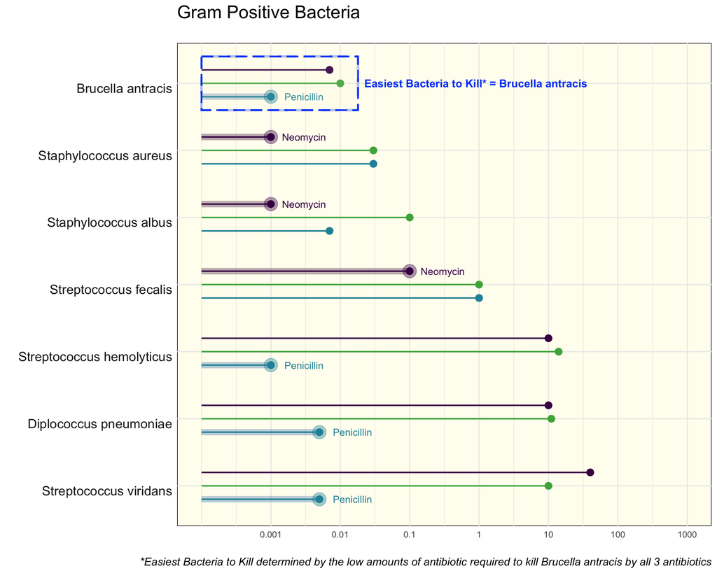

```r
antibio_labelled |>
  filter(Gram_Staining == "positive") |>
  ggplot(aes(y = fct_relevel(Bacteria, c(
                                         "Streptococcus viridans",
                                         "Diplococcus pneumoniae",
                                         "Streptococcus hemolyticus",
                                         "Streptococcus fecalis",
                                         "Staphylococcus albus",
                                         "Staphylococcus aureus",
                                         "Brucella antracis")),
             colour = fct_relevel(Antibiotic, c("Penicillin", "Streptomycin", "Neomycin")))) +
  geom_point(aes(x = MIC), position = position_dodge(width = 0.6), size = 3) +
  geom_segment(aes(x = 0.0001, y = 6.8, xend = 0.001, yend = 6.8), linewidth = 3, color = alpha("#2291A7", 0.02)) +
  geom_segment(aes(x = 0.0001, y = 6.2, xend = 0.001, yend = 6.2), linewidth = 3, color = alpha("#440154FF", 0.02)) +
  geom_segment(aes(x = 0.0001, y = 5.2, xend = 0.001, yend = 5.2), linewidth = 3, color = alpha("#440154FF", 0.02)) +
  geom_segment(aes(x = 0.0001, y = 2.8, xend = 0.001, yend = 2.8), linewidth = 3, color = alpha("#2291A7", 0.02)) +
  geom_segment(aes(x = 0.0001, y = 4.2, xend = 0.1, yend = 4.2), linewidth = 3, color = alpha("#440154FF", 0.02)) +
  geom_segment(aes(x = 0.0001, y = 1.8, xend = 0.005, yend = 1.8), linewidth = 3, color = alpha("#2291A7", 0.02)) +
  geom_segment(aes(x = 0.0001, y = 0.8, xend = 0.005, yend = 0.8), linewidth = 3, color = alpha("#2291A7", 0.02)) +
  geom_linerange(aes(xmin = 0.0001, xmax = MIC), position = position_dodge(width = 0.6), linewidth = 0.7) +
  scale_color_manual(values = c("#2291A7","#4daf4a","#440154FF")) +
  scale_x_continuous(transform = c("log10"),
                     limits = c(0.0001, 1000),
                     breaks = c(0.001, 0.01, 0.1, 1.0, 10, 100, 1000),
                     labels =  c(0.001, 0.01, 0.1, 1.0, 10, 100, 1000)) +
  theme_minimal() +
  labs(title = "Gram Positive Bacteria",
       subtitle = "",
       x = "",
       y = "",
       color = "",
       shape = "",
       caption = "*Easiest Bacteria to Kill determined by the low amounts of antibiotic required to kill Brucella antracis by all 3 antibiotics") +
  theme(panel.background = element_rect(fill = scales::alpha("#FDE724", 0.09)),
        axis.text.y = element_text(size = 13,
                                   vjust = 1,
                                   color = "grey10"),
        plot.caption = element_text(size = 11, face = "italic"),
        plot.title = element_text(size = 18)) +
  guides(color = "none") +
  geom_text(aes(x = MIC*3, label = label), position = position_dodge(width = 0.6), size = 3.5) +
  annotate("rect", xmin = 0.0001, xmax = 0.018, ymin = 6.6, ymax = 7.4, linetype = "longdash", color = alpha("#004AF7", 0.3), fill = NA, linewidth = 1.2) +
  annotate("rect", xmin = 0.0001, xmax = 0.018, ymin = 6.6, ymax = 7.4, linetype = "longdash", color = "#004AF7", fill = alpha("lightyellow", 0.09), linewidth = 0.8) +
  annotate("text", x = 0.9, y = 7, color = "#004AF7", label = "Easiest Bacteria to Kill* = Brucella antracis", fontface = "bold") +
  annotate("point", x = 0.001, y = 6.8, color = alpha("#2291A7", 0.4), size = 6) +
    annotate("point", x = 0.001, y = 6.2, color = alpha("#440154FF", 0.4), size = 6) +
    annotate("point", x = 0.001, y = 5.2, color = alpha("#440154FF", 0.4), size = 6) +
    annotate("point", x = 0.001, y = 2.8, color = alpha("#2291A7", 0.4), size = 6) +
    annotate("point", x = 0.1, y = 4.2, color = alpha("#440154FF", 0.4), size = 6) +
    annotate("point", x = 0.005, y = 1.8, color = alpha("#2291A7", 0.4), size = 6) +
    annotate("point", x = 0.005, y = 0.8, color = alpha("#2291A7", 0.4), size = 6)
```

```r
#ggplotly(graph2)
```

### Chart 3

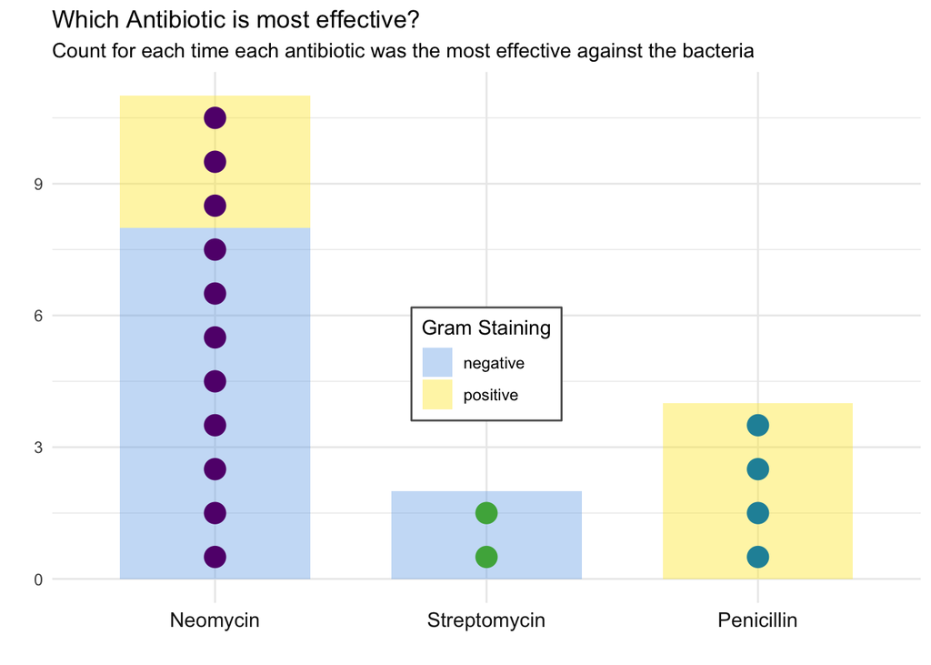

```r
antibio_long_new |>
  group_by(most_effective) |>
  arrange(Gram_Staining) |>
  mutate(dot_y = row_number() - 0.5) |>
  ggplot(aes(x = fct_relevel(most_effective, c("Neomycin", "Streptomycin", "Penicillin")))) +
    geom_bar(aes(fill = Gram_Staining), alpha = 0.4, position = position_stack(reverse = TRUE), width = 0.7) +
  geom_point(aes(y = dot_y, color = most_effective), size = 5) +
  #guides(fill = "none") +
  scale_fill_manual(values = c("#72ADE9", "#FDE724")) +
  scale_color_manual(values = c("Penicillin" ="#2291A7",
                                "Streptomycin" ="#4daf4a",
                                "Neomycin" = "#62117B")) +
  theme_minimal() +
  guides(color = "none") +
  labs(title = "Which Antibiotic is most effective?",
       subtitle = "Count for each time each antibiotic was the most effective against the bacteria",
       x = "",
       y = "",
       color = "",
       fill = "Gram Staining") +
  theme(legend.position = c(0.5, 0.45),
        legend.background = element_rect(fill = "white", color = "grey35"),
        axis.text.x = element_text(size = 11,
                                   color = "grey10")
        )
```

```r
#ggplotly(graph3)
```